# hw9

## b

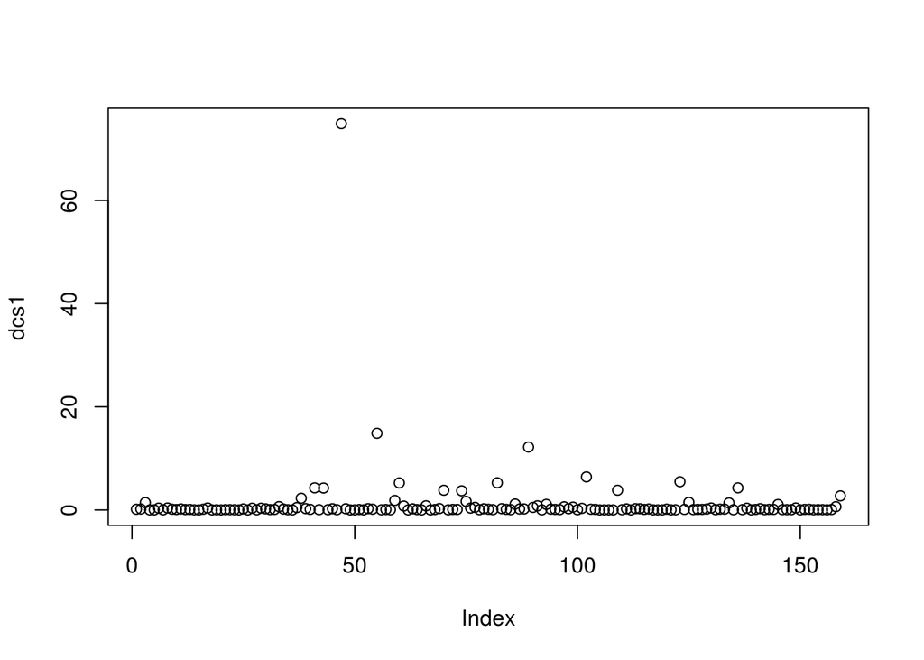

```r
#stendised pearson residual
spr1= residuals.glm(m1, "pearson")/sqrt(1 - lm.influence(m1)$hat)


# delta chisquare statitic
dcs1=spr1^2
plot(dcs1)
```

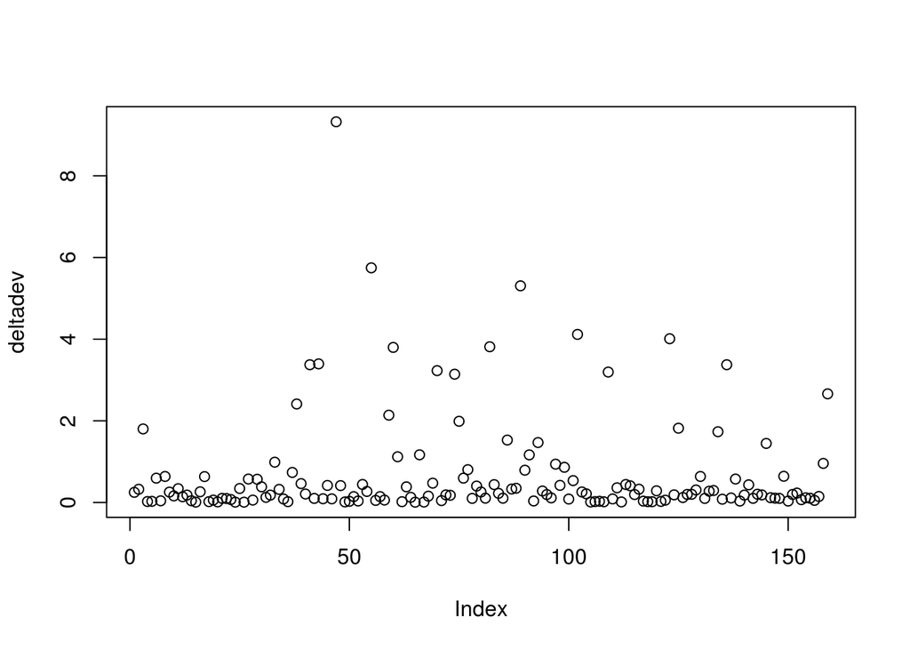

```r
# there seems to be a outlier as we can see

#delta deviance statistic
deltadev = lm.influence(m1)$hat * (spr1^2) + (residuals.glm(m1,type="deviance"))^2
plot(deltadev)
```

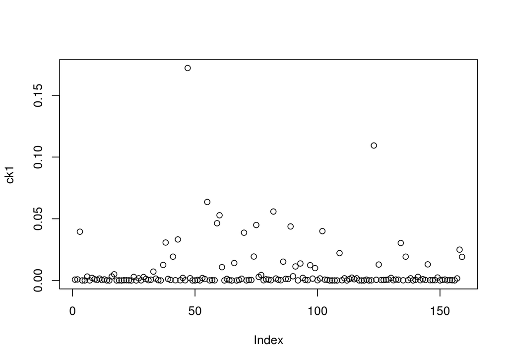

```r
#one outlier
ck1=cooks.distance(m1)
plot(ck1)
```

```r
# seems to be two outliers
```

# 14.36

# On the basis of the fitted regression func1ion in Problem 14.14a, obtain a confidence interval for the mean response n" for a female whose age is 65 and whose health awareness index is 50, with an approximate 90 percent family confidence coefficient. Interpret your intervals.

```r
p1=predict.glm(m1,newdata = data.frame(x1=65,x2=50,x3=0),se.fit = TRUE)
#alpha =0.10
ctval=qnorm(0.95)
lw1=p1$fit-(ctval*p1$se.fit)
up1=p1$fit+(ctval*p1$se.fit)


prlw=exp(lw1)/(1+exp(lw1))
prup=exp(up1)/(1+exp(up1))

#confidence Intervals
print(prlw)
```

```
##         1
## 0.1134639
```

```r
print(prup)
```

```
##         1
## 0.3241667
```

```r
#Interpretation
## at the given X values there is a 90% chance that the Expected value can be in the range of the following
```

## b

```r
cutoff<-seq(0.05,0.2, by=0.05)
risk<-m1$fitted.values
for(c1 in cutoff){
   pred.shot<-(risk>c1)
   enotd=table(pred.shot[flu$y==0])[2]/length(flu$y[flu$y==0])
   ewithd= table(pred.shot[flu$y==1])[1]/length(flu$y[flu$y==1])
   toterr=enotd+ewithd
   eror=round(c(c1,enotd,ewithd,toterr),2)
   print(eror)
}
```

```
##        TRUE FALSE  TRUE
##  0.05  0.63  0.04  0.67
##        TRUE FALSE  TRUE
##  0.10  0.41  0.12  0.53
##        TRUE FALSE  TRUE
##  0.15  0.28  0.17  0.45
##        TRUE FALSE  TRUE
##  0.20  0.16  0.42  0.58
```

# c

as we can see above when cutoff is 0.15 the error rate is minimum

the balnce is not very equal but it is the best available so we can call it best,however we cannot say it is balanced

```r
library(ROCR)
```

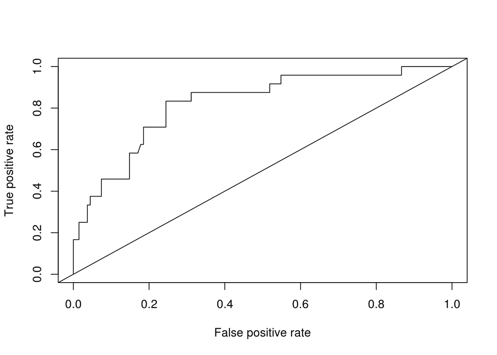

```r
pred <- prediction(m1$fitted.values, labels=flu$y )
perf <- performance(pred, "tpr", "fpr")
plot(perf)
abline(0,1)
```

```r
# as we can see the area is maximum at some where 0.8
```

# d

the best way is to have a seperate validation set and do the same calculation, if the values are near by then we can say that it is good for prediction